# Reproducible Research: Peer Assessment 1

In this codebook, we will complete the instrusticons step by step in the given order. According to the research pipepline, we will have some processing and analytic code in this codebook.

## Phase 1: Parsing Data

As you can see from the directory we are working on, we have our dataset as a ZIP file we will first unzip the file and gather the dataset from the new directory

```r
#First, let's learn our directory and set it to a variable
directory <- getwd()

#Let's check for the filename and append it to a variable and unzip that file.
datazip <-list.files(directory, pattern = ".zip")
unzip(datazip)

#Check for the name of the dataset and append it to a variable
filename <- list.files(directory, ".csv")

#Load data and append it to a variable
activity <- read.csv(file= filename, colClasses = "character", na.strings = "NA")

#Create directory for saving plots
figurespath <- paste0(directory, "/", "figures")
suppressWarnings(dir.create(path = figurespath))

#Define column classes
#Steps: Number of steps taking in a 5-minute interval
activity$steps <- as.numeric(activity$steps)

#Date : The date on which the measurement was taken in YYYY-MM-DD
# We will use *lubridate* package to transform date column from character to date

suppressMessages(library(lubridate))
activity$date <- ymd(activity$date)

#Interval : Identifier for the 5-minute interval in which measurement was taken
activity$interval <- as.numeric(activity$interval)

#Lets's check out data frame's information.
str(activity)
```

```
## 'data.frame':    17568 obs. of  3 variables:
##  $ steps   : num  NA NA NA NA NA NA NA NA NA NA ...
##  $ date    : Date, format: "2012-10-01" "2012-10-01" ...
##  $ interval: num  0 5 10 15 20 25 30 35 40 45 ...
```

## Phase II: Question #1- What is mean total number of steps taken per day?

```r
library(ggplot2)
suppressMessages(library(dplyr))

spd <- suppressMessages(activity %>% group_by(date) %>%
     summarize(sumSteps= sum(steps, na.rm = TRUE)))

#As we can ignore the incomplete cases, let's remove them
spd <- spd[complete.cases(spd),]

#Let's check our table before creating a histogram
head(spd)
```

```
## # A tibble: 6 x 2
##   date       sumSteps
##   <date>        <dbl>
## 1 2012-10-01        0
## 2 2012-10-02      126
## 3 2012-10-03    11352
## 4 2012-10-04    12116
## 5 2012-10-05    13294
## 6 2012-10-06    15420
```

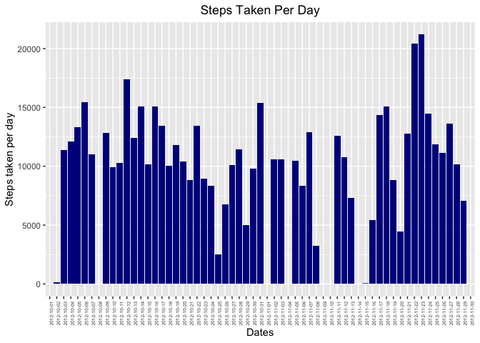

```r
#Create a histogram

ggplot(data=spd, aes(x=factor(date), y=sumSteps)) +
     geom_bar(stat="identity", fill="darkblue") +
     xlab("Dates")+
     ylab("Steps taken per day") +
     ggtitle("Steps Taken Per Day") +
     theme(axis.text.x = element_text(angle = 90, size = 5)) +
     theme(plot.title = element_text(hjust = 0.5))
```

```r
#Save the plot
suppressMessages(ggsave("plot1.png", path = figurespath, device = "png"))
```

Let’s calculate the mean and median

```r
spd %>% summarize(meanSteps = mean(sumSteps, na.rm = TRUE),
                  medianSteps = median(sumSteps, na.rm = TRUE))
```

```
## # A tibble: 1 x 2
##   meanSteps medianSteps
##       <dbl>       <dbl>
## 1     9354.       10395
```

## Phase III: Question #2: What is the average daily activity pattern?

First, group steps by interval and create the table using *ggplot2* package

```r
suppressMessages(stepsInterval <- suppressWarnings(activity %>% group_by(interval) %>%
     summarize(average= mean(steps, na.rm = TRUE))))

#Check the newly created dataset
head(stepsInterval)
```

```
## # A tibble: 6 x 2
##   interval average
##      <dbl>   <dbl>
## 1        0  1.72
## 2        5  0.340
## 3       10  0.132
## 4       15  0.151
## 5       20  0.0755
## 6       25  2.09
```

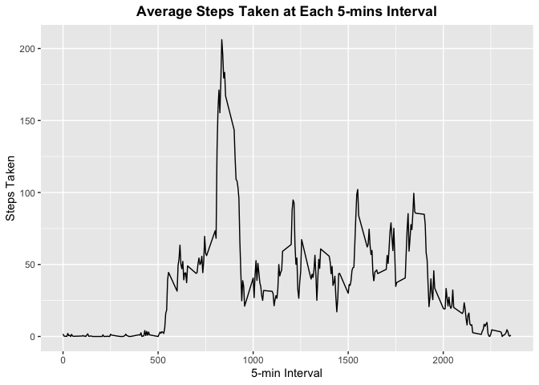

```r
ggplot(data= stepsInterval, aes(x=interval, y= average)) +
     geom_line() + xlab("5-min Interval") + ylab("Steps Taken") +
     ggtitle("Average Steps Taken at Each 5-mins Interval") +
     theme(plot.title = element_text(hjust=0.5, face = "bold"))
```

```r
#Save the plot
suppressMessages(ggsave("plot2.png", path = figurespath, device = "png"))
```

Let’s calculate the “In which interval, the steps were at the maximum number on average?”

```r
stepsInterval[which.max(stepsInterval$average),]
```

```
## # A tibble: 1 x 2
##   interval average
##      <dbl>   <dbl>
## 1      835    206.
```

## Phase IV: Imputing Missing Values

1. Calculate the total number of rows with missing values

```r
incomplete_cases <- sum(!complete.cases(activity))
print( paste0("Number of rows with missing values are : ", as.character(incomplete_cases)))
```

```
## [1] "Number of rows with missing values are : 2304"
```

2. Strategy for filling NAs

My strategy for filling the NAs in each column: Calculate the 5-mins interval for each interval and append the calculated value to the NAs for the respective column.

```r
# First, check which columns has NA values

any(is.na(activity$steps))
```

```
## [1] TRUE
```

```r
any(is.na(activity$date))
```

```
## [1] FALSE
```

```r
any(is.na(activity$interval))
```

```
## [1] FALSE
```

```r
# Calculte the average steps for each interval. We actually calculated this and
# stored in *stepsInterval*. Let's see it.

head(stepsInterval)
```

```
## # A tibble: 6 x 2
##   interval average
##      <dbl>   <dbl>
## 1        0  1.72
## 2        5  0.340
## 3       10  0.132
## 4       15  0.151
## 5       20  0.0755
## 6       25  2.09
```

3. Creating the new dataset As we know which values to append right now, let’s create a new dataset with no missing values. We can use *ifelse()* function. We will test if it is NA, if yes, append value from *stepsInterval* dataset if no, continue with existing.

```r
newactivity <- activity

newactivity$steps <- ifelse(is.na(newactivity$steps), stepsInterval$average,
                            newactivity$steps)
```

4. Number of steps taken each day

We will create an histogram for steps taken each day with this new dataset. We will first create a table that contains the sum of steps for each day and create the plot.

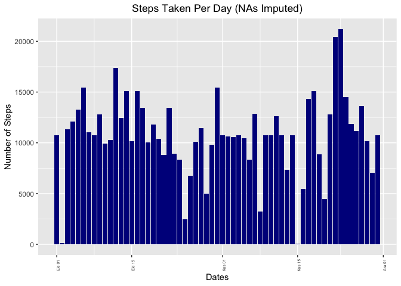

```r
suppressMessages(spd_new <- newactivity %>% group_by(date) %>% summarize(totalSteps = sum(steps)))

ggplot(data=spd_new, aes(x=date, y= totalSteps)) +
     geom_bar(stat= "identity", fill= "darkblue")+
     xlab("Dates")+
     ylab("Number of Steps") +
     ggtitle("Steps Taken Per Day (NAs Imputed)") +
     theme(axis.text.x = element_text(angle = 90, size = 5)) +
     theme(plot.title = element_text(hjust = 0.5))
```

```r
#Save the plot

suppressMessages(ggsave("plot3.png", path = figurespath, device = "png"))
```

5. Mean and median of steps

We have already created a dataset that contains steps taken in each day. We will use that dataset to calculate the mean and median.

```r
spd_new %>% summarize(meanSteps = mean(totalSteps), medianSteps = median(totalSteps))
```

```
## # A tibble: 1 x 2
##   meanSteps medianSteps
##       <dbl>       <dbl>
## 1    10766.      10766.
```

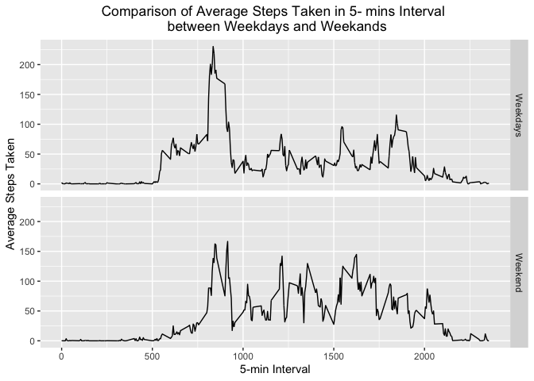

```r
#Create days variable

newactivity$days <- weekdays(newactivity$date, abbreviate = TRUE)

#Create a new variable for weekdays/weekends.

newactivity$part <- ifelse(newactivity$days %in% c("Cts", "Paz"), "Weekend", "Weekdays")

# Create a table that summarizes the results by grouping on dates and weekdays/weekends
suppressMessages(steps_part <- newactivity %>%
     group_by(interval,part) %>% summarize(interval = interval,
                                            totalSteps = mean(steps),
                                            part = part))

#Draw plot
ggplot(data=steps_part, aes(x=interval, y=totalSteps)) +
     geom_line() +
     facet_grid(part ~ .) +
     xlab("5-min Interval") +
     ylab("Average Steps Taken") +
     ggtitle("Comparison of Average Steps Taken in 5- mins Interval \n between Weekdays and Weekands") +
     theme(plot.title = element_text(hjust = 0.5))
```

```r
#Save Plot
suppressMessages(ggsave("plot4.png", path = figurespath, device = "png"))
```

## Phase VI: Knit the Document

```r
library(knitr)
library(rmarkdown)
```

After loading these packages, click the “Knit” option in the GUI system of RStudio. It is in the toolbar of the left upper quadrant window.